# Tissot’s Indicatrix Explained (using R)

## Introduction

When converting spatial features from a geographic coordinate system (GCS) to a projected coordinate system (PCS) one or more spatial properties may be distorted in the transformation. These properties include **area**, **shape**, **distance** and **direction** .

Nicolas Tissot’s *indicatrix* (TI) is designed to quantify the amount of distortion in a map projection. The idea is to project a small circle (i.e. small enough so that the distortion remains relatively uniform across the circle’s extent) and to measure its distorted shape on the projected map.

For example, the following figure shows TIs across the continental US when presented in a Gnomonic projection centered at 100° West and 30° North.

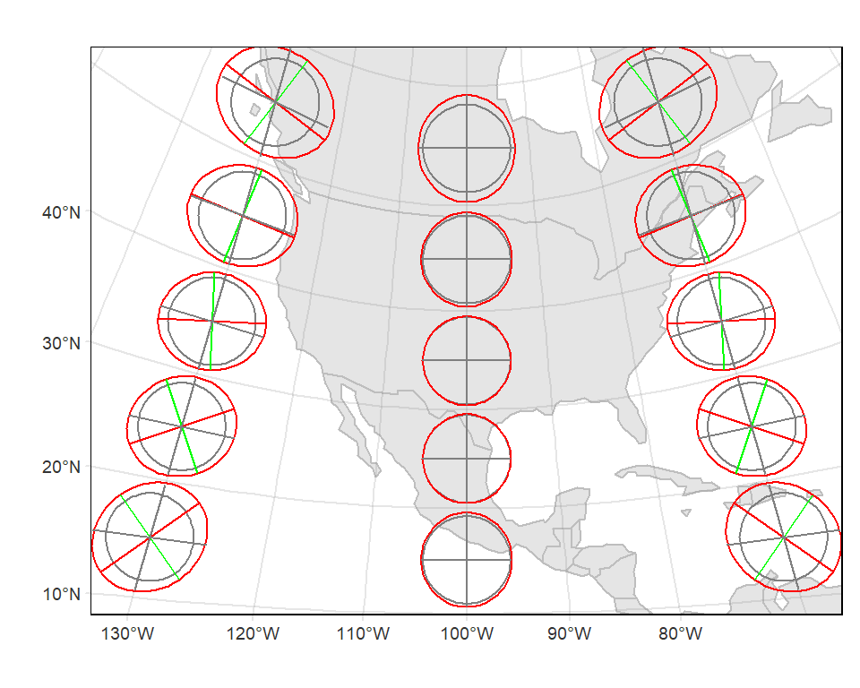

Let’s explore a Tissot indicatrix (TI) in more detail at -69.5° West and 44.5° North (somewhere in central Maine, USA).

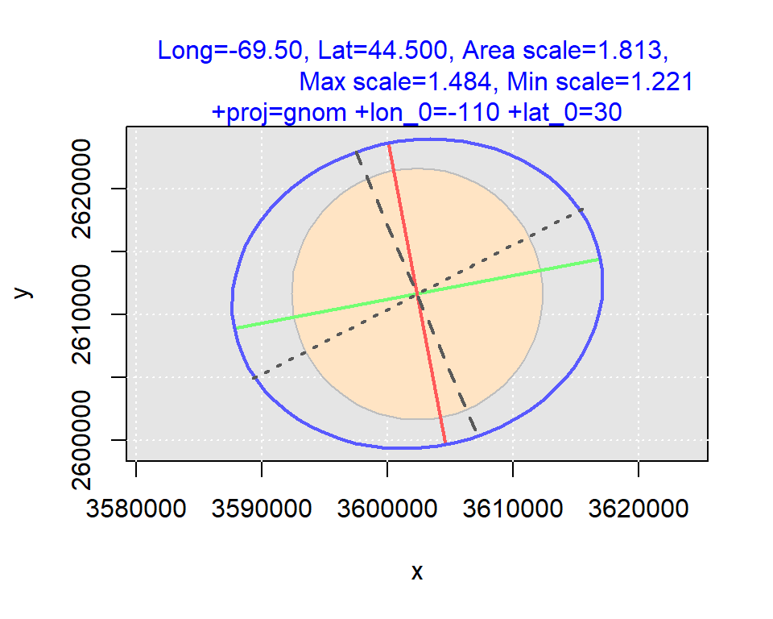

The **blue ellipse** (the indicatrix) is the transformed circle in this particular projection (+proj=gnom +lon_0=-110 +lat_0=30). The **green** and **red** lines show the magnitude and direction of the ellipse’s major and minor axes respectively. If these axes are not equal (i.e. if the ellipse has a non-zero eccentricity), the projection is said *not* to be **conformal** at this location. These lines can also be used to assess scale distortion which can vary as a function of bearing as seen in this example. The green line shows the largest scale distortion and the red line shows the smallest scale distortion–these are sometimes referred to as the **principal directions**. In this working example, the principal directions are 1.484 and 1.221 respectively. A scale value of `1` indicates no distortion. A value less than `1` indicates a smaller-than-true scale and a value greater than `1` indicates a greater-than-true scale.

Not only can shape be distorted, but its **area** can be as well. The bisque colored circle at the center of the ellipse represents a **base circle** as represented in this gnomonic projection. It’s much smaller than the indicatrix. The indicatrix is 1.813 times greater than the base circle. In other words, an area will be exaggerated 1.813 times at this location given this gnomonic projection.

Other features of this indicatrix include The **north-south** dashed line which is aligned with the meridian and the **east-west** dotted line which is aligned with the parallel. These lines are used to assess if meridians and parallels intersect at right angles.

## Generating Tissot circles

### Loading a few functions and base layers

A group of functions are available on the github website and can be sourced via:

```r
library(sf)
library(rgdal)
library(tmap)

# Load a few functions
source("https://raw.githubusercontent.com/mgimond/tissot/master/Tissot_functions.r")
```

This tutorial will also make use of a few base layers used as a reference.

```r
world <-  readRDS(gzcon(url("https://github.com/mgimond/tissot/raw/master/smpl_world.rds")))
us <-  readRDS(gzcon(url("https://github.com/mgimond/tissot/raw/master/smpl_US.rds")))
```

### Defining a few projections

If you are not familiar with R’s coordinate system environment, you might want to skim through [this web site](https://mgimond.github.io/Spatial/coordinate-systems-in-r.html). In this next chunk of code, we’ll create a few projection objects for use later in this tutorial.

```r
# USA Lambert Conformal
proj.lcc    <- "+proj=lcc +lat_1=33 +lat_2=45 +lat_0=39 +lon_0=-96 +datum=NAD83"
# Equal area conic
proj.aea    <- "+proj=aea +lat_1=30 +lat_2=45 +lat_0=37.5 +lon_0=-96 +datum=NAD83"
# Equidistant conic
proj.eqdc   <- "+proj=eqdc +lat_0=37.5 +lon_0=-96 +lat_1=30 +lat_2=45 +datum=WGS84"
# Mercator
proj.merc   <- "+proj=merc +ellps=WGS84"
# Planar projection
proj.ortho1 <- "+proj=ortho +lon_0=-69 +lat_0=45 +ellps=WGS84"
# UTM NAD83
proj.utm19N <- "+proj=utm +zone=19 +ellps=GRS80 +datum=NAD83"
# Equal Area Cylindrical projection
proj.cea    <- "+proj=cea +lon_0=0 +lat_ts=0 +x_0=0 +y_0=0 +ellps=WGS84"
# Plate Carree
proj.carree <- "+proj=eqc +lat_ts=0 +lat_0=0 +lon_0=0 +ellps=WGS84 +datum=WGS84"
# Azimuthal Equidistant
proj.aeqd   <- "+proj=aeqd +lat_0=45 +lon_0=-69 +datum=WGS84"
# Gnomonic
proj.gnom   <- "+proj=gnom +lon_0=-100 +lat_0=30 +ellps=WGS84"
```

We’ll also define the input coordinate system used throughout this exercise. This CS will be used to define the lat/long values of the TI centers.

```r
proj.in <- "+proj=longlat +datum=WGS84"
```

### Mercator projection indicatrix

We’ll start off by exploring a **Mercator** projection (a popular projection found on many mapping websites).

First, we’ll define point locations where we will want to evaluate projection distortions. We’ll automate the point creation process by *gridding* the point distribution.

```r
lat <- seq(-80,80, by=20L)
lon <- seq(-170,170, by=34L)
coord <- as.matrix(expand.grid(lon,lat))
```

Next, we’ll run the `coord_check()` function (one of the functions sourced earlier in this tutorial) to remove any points that may fall outside of the Mercator’s practical extent.

```r
coord2 <- coord_check(coord, proj.out = proj.merc)
```

Next, we’ll generate the indicatrix parameters for these points using the custom `ti()` function.

```r
i.lst <- apply(coord2,1, function(x) ti(coord = x, proj.out = proj.merc))
```

Next, we’ll create `sf` objects from these indicatrix parameters.

```r
tsf <- tissot_sf(i.lst, proj.out = proj.merc)
```

The output object `tsf` is a list consisting of the different indicatrix `sf` features. Each feature can be extracted from the list via its component name:

- `tsf$base` The base circle as represented by the projected CS (polygon)
- `tsf$ind` The indicatrix (polygon)
- `tsf$maja` The semi-major axis (polyline)
- `tsf$mina` The semi-minor axis (polyline)
- `tsf$lam` The parallel (polyline)
- `tsf$phi` The meridian (polyline)

Finally, we’ll plot the ellipses using the `tmap` package.

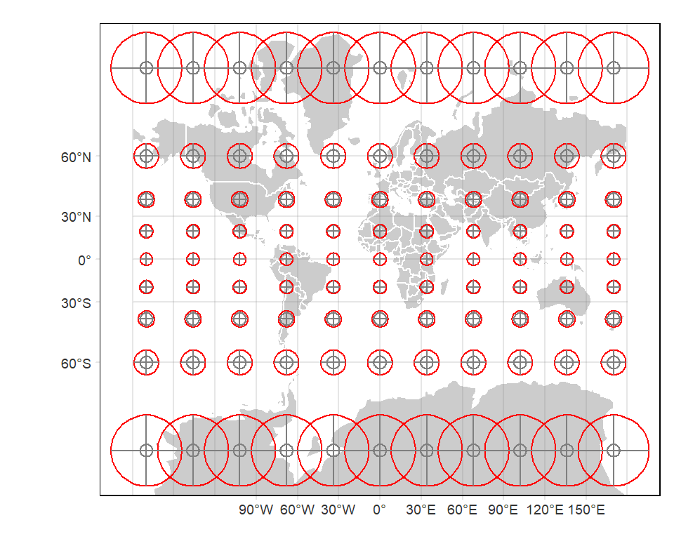

```r
tm_shape(world, projection = CRS(proj.merc), bbox = tsf$ind) +
  tm_polygons(col = "grey80", border.col = "white") +
  tm_shape(tsf$base) + tm_borders(col="grey50") +
  tm_shape(tsf$ind)  + tm_borders(col="red") +
  tm_shape(tsf$mina) + tm_lines(col="red") +
  tm_shape(tsf$maja) + tm_lines(col="green") +
  tm_shape(tsf$lam)  + tm_lines(col="grey50") +
  tm_shape(tsf$phi)  + tm_lines(col="grey50") +
  tm_graticules(alpha=0.2)
```

The Mercator projection is conformal in that the shape of the circle remains a circle. Also, its lines of longitude and latitude remain at right angles across the entire map extent. Its area and scale, however, is heavily distorted as one approaches the poles.

A separate function, `TI_local()` is available that allows you to explore the indicatrix in more detail at a single point location. For example, to explore the Mercator distortion at a location in central Maine (USA), type:

```r
ti.maine <- local_TI(long = -69.5, lat = 44.5, proj.out = proj.merc)
```

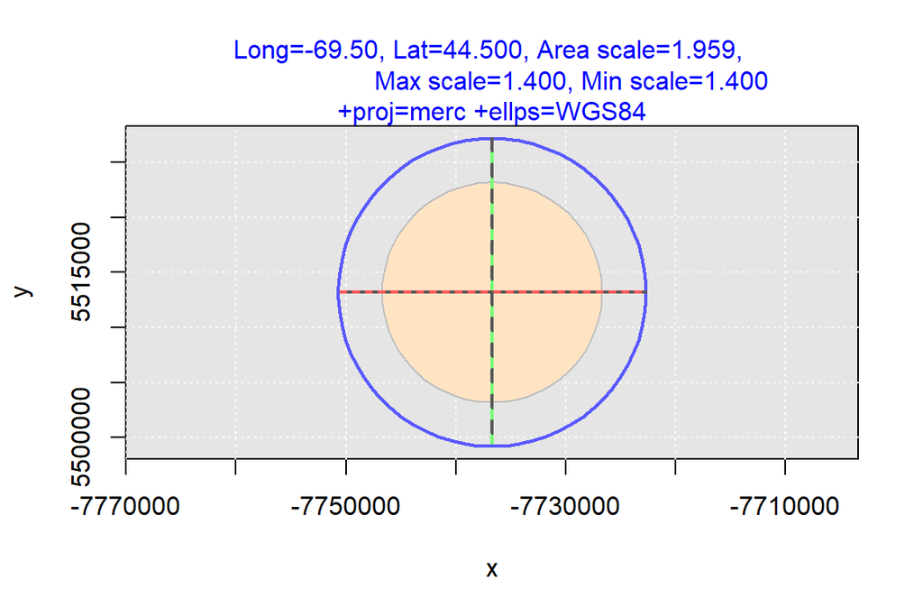

You can extract indicatrix parameters from the `ti.maine` object generated from this function. For example, to extract the area scale, type:

```r
ti.maine$scale.area
```

```
[1] 1.959244
```

Likewise, to extract the principal direction scales, type:

```r
ti.maine$max.scale
```

```
[1] 1.399736
```

```r
ti.maine$min.scale
```

```
[1] 1.399725
```

### Custom function

Going forward, we will rerun many of the code chunks executed earlier in this exercise. To reduce code clutter going forward, we will create a custom function that will take as input projection type (`proj.out`) and tissot center locations.

```r
ti.out <- function(proj.in = proj.in, proj.out, lat, lon, bmap = world,
                   plot = TRUE, base_fill = TRUE,
                   grt.lon = seq(-180,180,by=30), grt.lat = seq(-90,90,by=30)){
  coord1 <- as.matrix(expand.grid(lon,lat))
  coord2 <- coord_check(lonlat =coord1, proj.out = proj.out)
  i.lst <- apply(coord2,1, function(x) ti(coord = x, proj.out = proj.out))
  tsf <- tissot_sf(i.lst, proj.out = proj.out)

  if(plot == TRUE){
    # Re-project the world
    bmap.prj <- st_transform(bmap, crs = proj.out, check = TRUE)

    # Create graticule
    grt <- st_graticule(crs = proj.in, lon = grt.lon, lat = grt.lat)

    base.out <- if(base_fill) {
          tm_polygons(col="grey80", border.col = "white")
     } else {
          tm_borders(col="grey50")
     }

    # Generate plot
    tm_shape(bmap.prj, bbox = tsf$ind) +
      base.out +
      tm_shape(tsf$base) + tm_borders(col="grey50") +
      tm_shape(tsf$ind)  + tm_borders(col="red") +
      tm_shape(tsf$mina) + tm_lines(col="red") +
      tm_shape(tsf$maja) + tm_lines(col="green") +
      tm_shape(tsf$lam)  + tm_lines(col="grey50") +
      tm_shape(tsf$phi)  + tm_lines(col="grey50") +
      tm_shape(grt) + tm_lines(col = "grey80")
  } else{
    return(tsf)
  }
}
```

### Equal area cylindrical projection

Next, we’ll explore another cylindrical coordinate system that, unlike the Mercator projection, preserves area.

We’ll run the same chunks of code used in the last section, but we’ll replace all references to the output projected coordinate system with the `proj.cea` projection object.

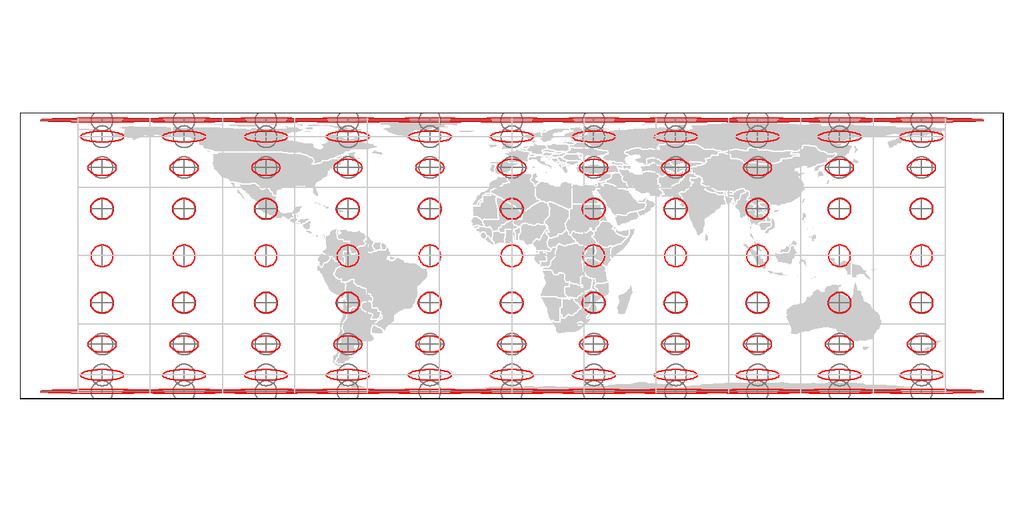

```r
# Define point coordinates for TI polygons
lat <- seq(-80, 80, by = 20L)
lon <- seq(-170, 170, by = 34L)

# Generate map
ti.out(proj.out = proj.cea, lat = lat, lon = lon)
```

Note the flattening of features as one progresses pole-ward. This compensates for the east-west stretching of features nearer the poles. Let’s check an indicatrix up close at the 44.5° latitude.

```r
ti.maine <- local_TI(long = -69.5, lat = 44.5, proj.out = proj.cea)
```

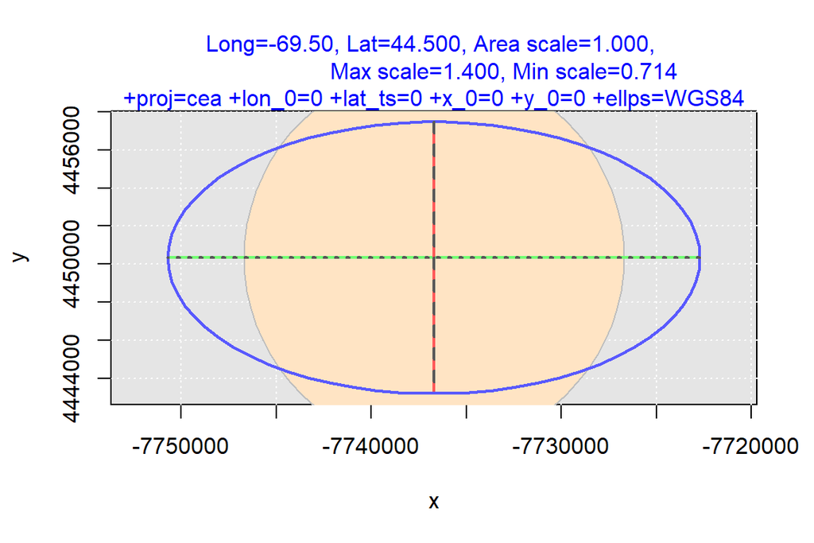

The area is indeed preserved, but this comes at a cost. The projection is not conformal except near the equator (this is where the projection makes contact with the earth’s ellipsoid). At the 44.5° latitude, the east-west scale is increased by 1.4 and decreased by 0.7 along the north-south axis.

### Earth-from-space planar projection

Let’s explore another family of projections: an orthographic projection.

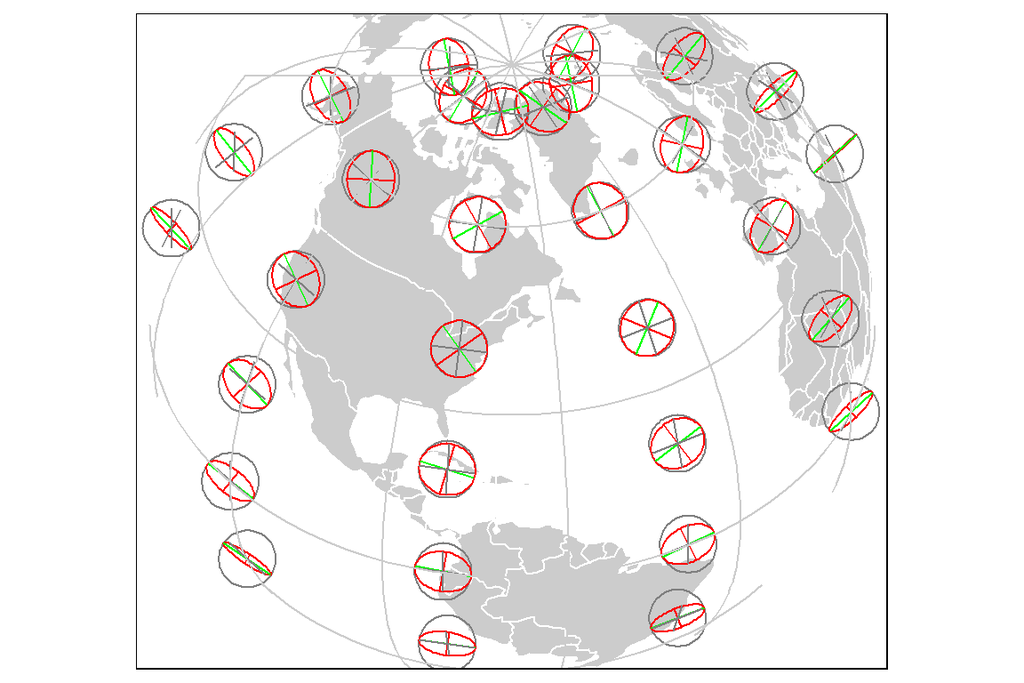

```r
lat <- seq(-20, 80, by = 20L)
lon <- seq(-160, 40, by = 40L)
ti.out(proj.out = proj.ortho1, lat = lat, lon = lon)
```

This particular coordinate system has the center of the projection touching the earth’s surface. As such, you expect minimal distortion at the center (here the projection is centered at -69° longitude and 45° latitude).

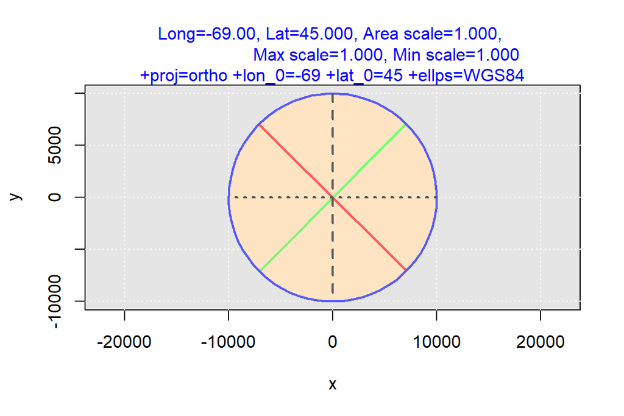

```r
local_TI(long = -69, lat = 45, proj.out = proj.ortho1)
```

Distortion in area and length increases as one moves away from the projection’s center as shown in the next TI centered at 0° longitude and 80° latitude.

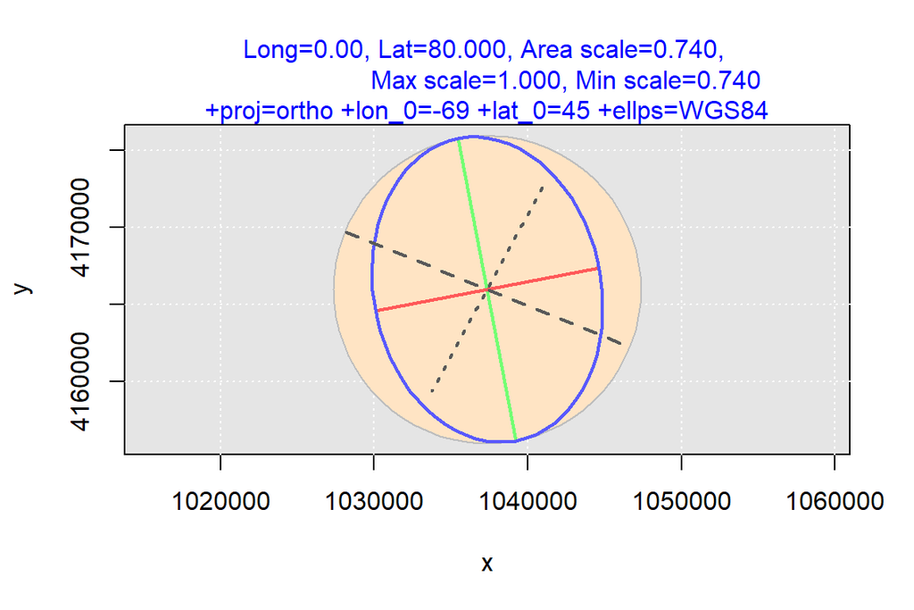

```r
local_TI(long = 0, lat = 80, proj.out = proj.ortho1)
```

### USA Contiguous Lambert Conformal Conic Projection

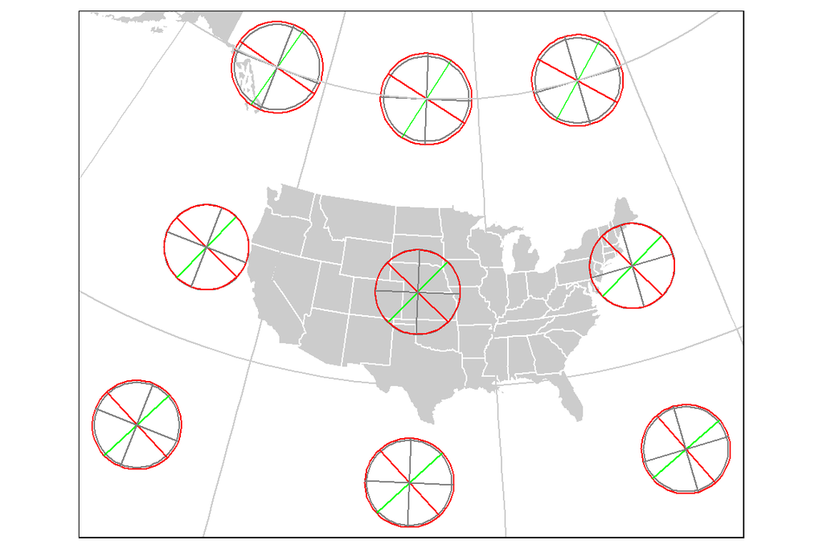

```r
lat <- seq(20, 60, by = 20L)
lon <- seq(-130, -70, by = 30L)
ti.out(proj.out = proj.lcc, lat = lat, lon = lon, bmap = us)
```

Let’s explore one of the TI polygons in greater detail. We’ll zoom in on (60°N, 130°W).

```r
ti_lcc <- local_TI(long = -130, lat = 60, proj.out = proj.lcc)
```

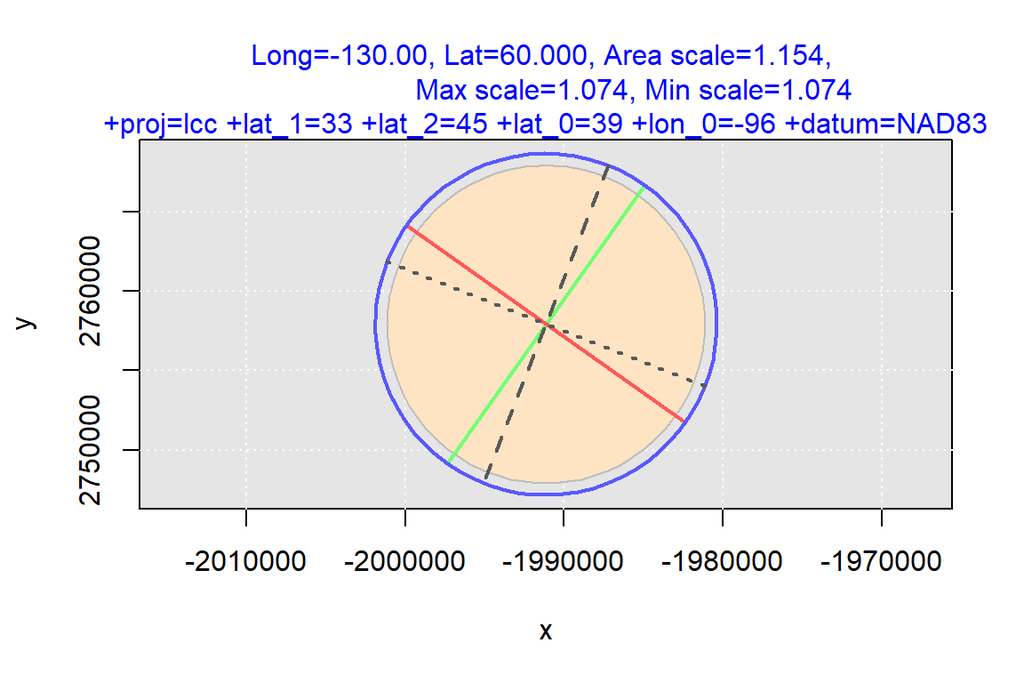

The TI appears circular. We can quantify the distortion in shape by extracting the angle between the parallel and meridian lines at the TI’s center from the `ti_lcc` object (these are shown as the two dashed lines in the TI). A conformal projection is one that preserves angle, so we would expect a value of 90° between the two reference lines.

```r
ti_lcc[[12]][3]  # Extract the intersecting angle
```

```
intersection_angle
          89.99917
```

```r
ti_lcc$scale.area
```

```
[1] 1.154365
```

```r
ti_lcc$max.scale
```

```
[1] 1.074422
```

```r
ti_lcc$min.scale
```

```
[1] 1.074405
```

Note that for this projection to preserve shape, both principal directions most have the same length (as is the case in our working example with a scale of 1.074).

## Generating areal scale factor raster

We can generate a continuous (raster) surface of areal scale values. This can prove helpful in visualizing the distortion associated with the PCS across the *whole* map extent.

We’ll first create a custom function

```r
library(raster)

r.out <- function(ll, ur, prj.out, plot = TRUE, grt = TRUE, bgmap = world,
                  nrows = 28, ncols = 32) {
  ll.prj <- prj2(ll, proj.out = prj.out)
  ur.prj <- prj2(ur, proj.out = prj.out)

# Define raster extent in the native PCS (note that the choice of extent and
# grid size may generate instabilities in the projected values)
ext.prj <- extent(matrix(c(ll.prj[1], ll.prj[2], ur.prj[1], ur.prj[2]), nrow = 2))
r <- raster(ext.prj, nrows = nrows, ncols = ncols, crs = prj.out, vals = NA)

# Extract coordinate values in native PCS
coord.prj <- raster::coordinates(r)

# Now convert to lat/long values
# Note that we are reversing the transformation direction, we are going
# from projected to geographic.
coord.ll <- t(apply(coord.prj, 1,
                    FUN = function(x) prj2(x, proj.in = prj.out,
                                           proj.out="+proj=longlat +datum=WGS84")))

# Compute Tissot area
i.lst <- apply(coord.ll, 1, function(x) ti_area(coord=x, proj.out = prj.out))
r[] <- round(i.lst,4)

# Reproject bgmap
 bgmap.prj <- st_transform(bgmap, proj.out, check = TRUE)

# Map the raster
out <- tm_shape(r) +
  tm_raster(palette = "Spectral", style="cont", midpoint = 1, title = "Scale") +
  tm_shape(bgmap.prj) + tm_borders(col="grey20") +
  tm_legend(outside = TRUE)

if (grt == TRUE) out <- out + tm_graticules()

if (plot == TRUE){
  out
}else{
  return(r)
}
}
```

### Orthographic projection

We’ll extend our analysis of the orthographic projection from the last section.

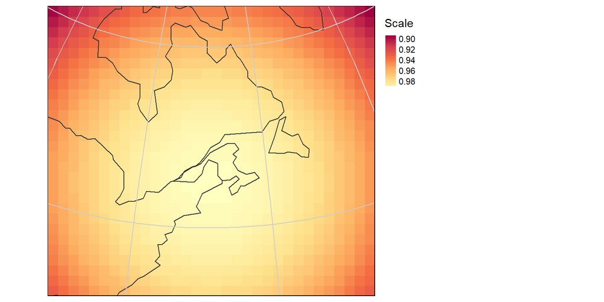

```r
proj.out <- proj.ortho1
ll <- c(xmin = -90, ymin = 30)
ur <- c(xmax = -30, ymax = 60)

# Create raster map (remove default graticule which is problematic for this
# projection)
out1 <- r.out(ll, ur, proj.out, plot = TRUE, grt= FALSE)

# Create a custom graticule
# tm_graticule() introduces artifacts for this orthographic projection,
# so a separate graticule is generated for this projection
grt <- st_graticule(x = c(-155, 0, -5, 90), crs = proj.in)

# Plot the data
out1 + tm_shape(grt) + tm_lines(col = "grey80")
```

This orthographic projection has a single point true scale centered at 69° West and and 45° North. The areal scale decreases as one moves away from the point. Given its areal and conformal distortions, this projection is not particularly useful other than to portray the earth viewed from space.

### UTM projection

Next, we’ll modify the previous chunk of code for use with a UTM coordinate system while limiting the extent to the state of Maine (USA). This will help us visualize the north-south strips of the projection where scale is close to 1 (this location coincides with UTM’s two standard lines).

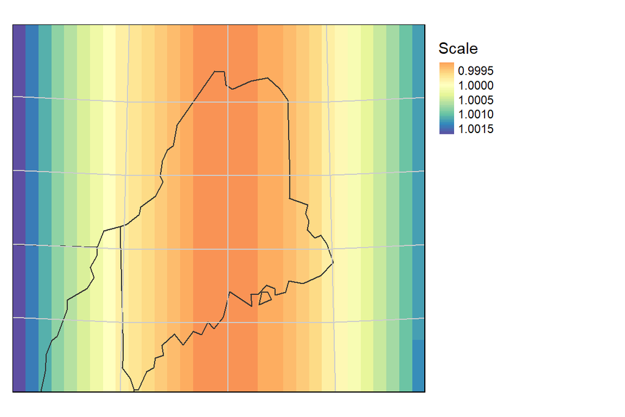

```r
proj.out <- proj.utm19N
ll <- c(xmin = -73, ymin = 43)
ur <- c(xmax = -65, ymax = 48)
out1 <- r.out(ll, ur, proj.out, bgmap = us, plot = TRUE, grt = FALSE)
grt <- st_graticule(crs = proj.in, lon = c(-71,-69,-67), lat = c(44,45,46,47))
out1 + tm_shape(grt) + tm_lines(col = "grey80")
```

The UTM projection adopts a secant projection whereby the cylindrical projection *contacts* the earth at two standard lines (they don’t quite follow meridians). As such, the areal scale between the two standard lines will be just under 1 at the central meridian and greater than 1 otherwise. The standard lines are 360 km apart of one another along the equator but decrease in distance as one travels pole-ward.

### Plate Carrée projection

A popular cylindrical coordinate system adopted as a standard projection for geographic data in GIS software like ArcGIS and QGIS is the Plate Carrée projection (or a derivative thereof). We’ll modify the previous chunk once again.

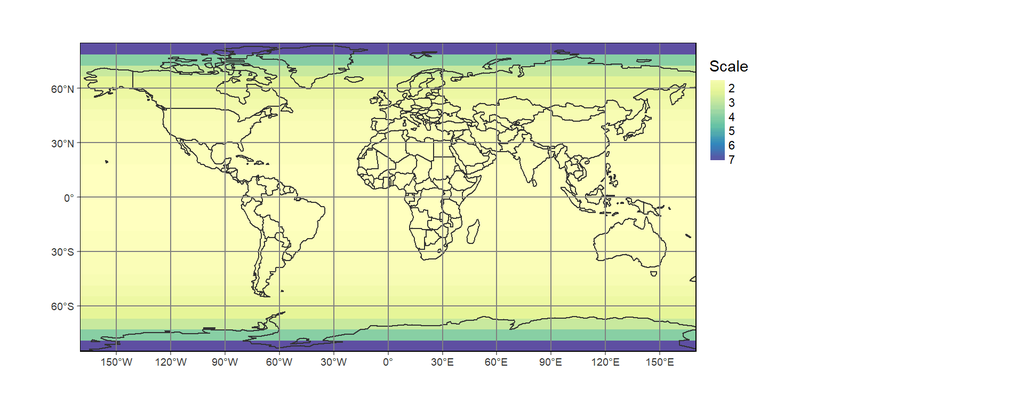

```r
proj.out <- proj.carree

ll <- c(xmin = -170, ymin = -85)
ur <- c(xmax = 170, ymax = 85)
r.out(ll, ur, proj.out)
```

You’ll note that the scale increases quite a bit as one moves away from the equator.

### Equal-area projection

Now let’s revisit the equal area projection. The Tissot indicatrix suggested that the projection did not preserve shape in an earlier example. A single Tissot indicatrix was generated at a 45° latitude suggesting that area was unaffected. Let’s generate an areal distortion raster to explore the extent of equal area projection.

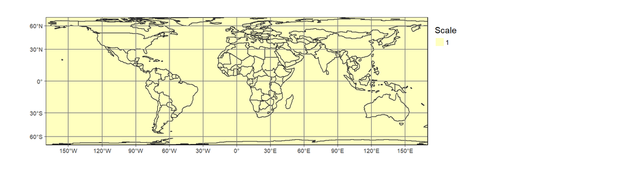

```r
proj.out <- proj.cea
ll <- c(xmin = -170, ymin = -85)
ur <- c(xmax = 170, ymax = 85)
r.out(ll, ur, proj.out)
```

The map makes it clear that the areal scale remains true (to at least 3 decimal places) for much of the earth’s extent.

# Combining indicatrix with areal scale factor raster

Next, we’ll overlap indicatrix ellipses with areal scale factor rasters. This will allow us to view both distortion in shape, length scale and as area.

## Equal-area projection

We’ll continue with the last projection used (the equal area projection).

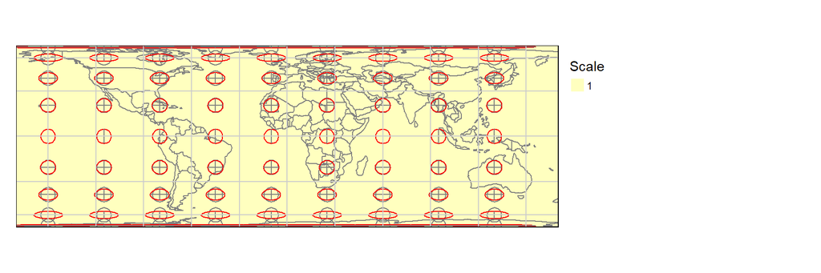

```r
proj.out <- proj.cea

# Raster extent
ll  <- c(xmin = -170, ymin = -85)
ur  <- c(xmax = 170, ymax = 85)

# TI polygon centers
lat <- seq(-80, 80, by = 20L)
lon <- seq(-150, 150, by = 35L)

# Areal scale factor raster
r1  <- r.out(ll, ur, proj.out, plot = FALSE)

# TI polygons
tsf  <- ti.out(proj.out = proj.out, lat = lat, lon = lon, base_fill = FALSE)

# Plot output
tm_shape(r1, projection = proj.out) +
  tm_raster(palette = "Spectral", style = "cont",
             midpoint = 1, title = "Scale") +
  tsf + tm_legend(outside = TRUE)
```

While the area scale remains true across the map’s extent, its shape clearly does not. Distortion of north-south and east-west scales is needed to ensure that the area is preserved.

## Gnomonic projection

One interesting coordinate system is the gnomonic projection. This projection is unique in that great circles (shortest distance on an ellipsoid) map to a straight line. In other words, the shortest distance between to points on this projected map is the true great circle distance. The following map is that of a gnomonic projection centered at 30° North and 100° West.

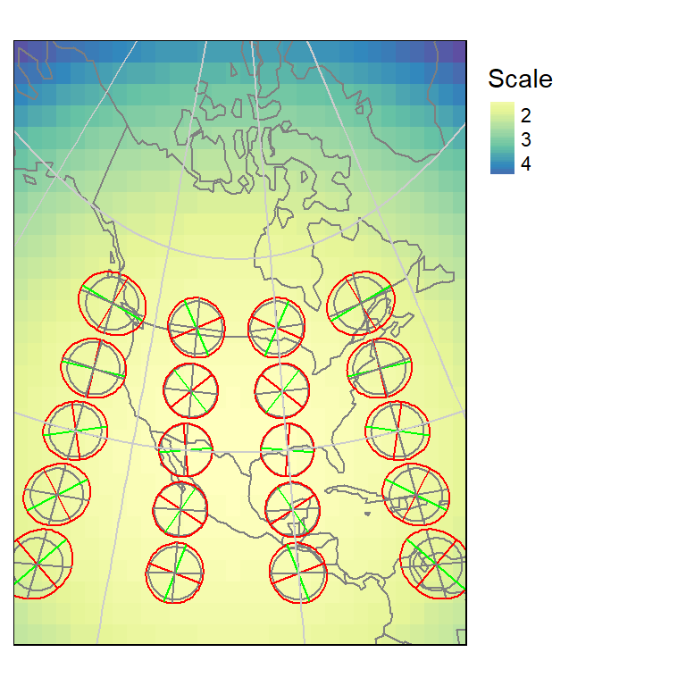

```r
proj.out <- proj.gnom

ll  <- c(xmin = -130, ymin = 0)
ur  <- c(xmax = -30, ymax = 65)
lat <- seq(10, 50, by = 10L)
lon <- seq(-130, -70, by = 20L)

r1  <- r.out(ll, ur, proj.out, plot = FALSE)
tsf  <- ti.out(proj.out = proj.out, lat = lat, lon = lon, base_fill = FALSE)

tm_shape(r1, projection = proj.out) +
  tm_raster(palette = "Spectral", style="cont",
            midpoint = 1, title = "Scale") +
  tsf + tm_legend(outside = TRUE)
```

## Equal-area conical projection

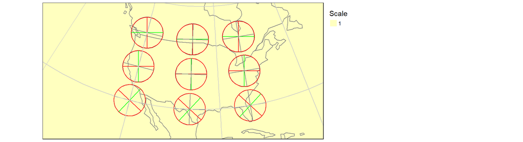

```r
proj.out <- proj.aea
ll  <- c(xmin = -140, ymin = 10)
ur  <- c(xmax = -40, ymax = 50)
lat <- seq(30, 50, by = 10L)
lon <- seq(-120, -70, by = 20L)
#r1  <- r.out(ll, ur, proj.out, plot = FALSE, nrows = 38, ncols = 50)
#tsf <- ti.out(proj.out = proj.out, lat=lat, lon=lon, plot = FALSE)

r1  <- r.out(ll, ur, proj.out, plot = FALSE)
tsf  <- ti.out(proj.out = proj.out, lat=lat, lon=lon, base_fill = FALSE)

tm_shape(r1, projection = proj.out) +
  tm_raster(palette = "Spectral", n = 8,
            midpoint = 1, title = "Scale") +
  tsf + tm_legend(outside = TRUE)
```

Area is well preserved across this extent (all pixels have a scale factor of 1. But if you look closely, length scale becomes slightly distorted as one moves away from the two standard lines (lines of exact scale). We can take a closer look at one of these indicatrices.

```r
ti.aea <- local_TI(-110, 10, proj.out = proj.out)
```

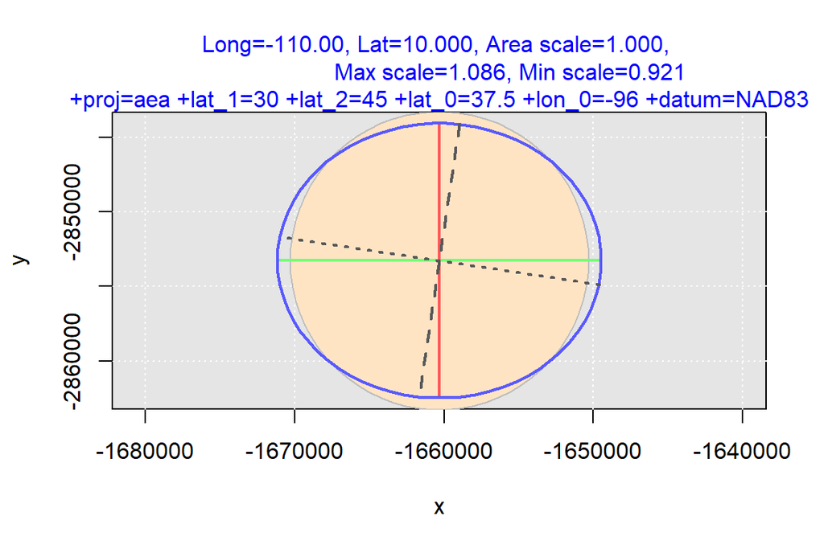

At a latitude of 10° (20° of the southern-most standard line) the areal scale remains unity, the length scale varies from 0.921 to 1.086 depending on the direction the distance is measured at.

## Equidistant conical projection

If distance is an important spatial property for your analysis, you can adopt an equidistant projection.

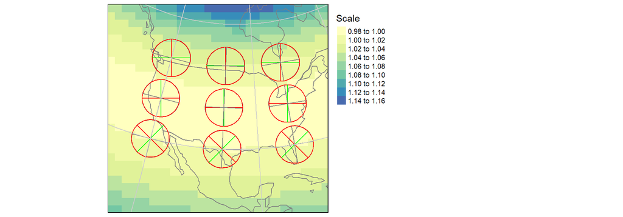

```r
proj.out <- proj.eqdc
ll  <- c(xmin = -125, ymin = 10)
ur  <- c(xmax = -55, ymax = 60)
lat <- seq(30, 50, by = 10L)
lon <- seq(-120, -70, by = 20L)

r1  <- r.out(ll, ur, proj.out, plot = FALSE)
tsf  <- ti.out(proj.out = proj.out, lat = lat, lon = lon, base_fill = FALSE)

tm_shape(r1) +
  tm_raster(palette = "Spectral", n = 8,
            midpoint = 1, title = "Scale") +
  tsf + tm_legend(outside = TRUE)
```

We can also extract the length measurements of the principal directions from the `tsf` object.

For the maximum scale distortions lengths for each TI, type:

```r
params  <- ti.out(proj.out = proj.out, lat = lat, lon = lon, plot = FALSE)
st_length(params$maja)
```

```
Units: [m]
[1] 1000006 1000005 1000004 1000000 1000000 1000000 1017590 1017590 1017590
```

The output units are those of the projection mapping units–meters in our example.

For the minimum scale distortions lengths for each TI, type:

```r
st_length(params$mina)
```

```
Units: [m]
[1]  999993.6  999994.7  999995.7  992245.2  992245.2  992245.2 1000000.1
[8] 1000000.0 1000000.1
```

To preserve distance scales across the map’s extent, area scale needs to be compromised. The scale ranges from 0.98 to 1.16 within the bounds defined by `ll` and `ur`.

*All code in this tutorial were created with the following external libraries*

| GEOS | 3.8.0 |
| --- | --- |
| GDAL | 3.0.4 |
| proj.4 | 6.3.1 |
| GDAL_with_GEOS | true |
| USE_PROJ_H | true |

Manny Gimond, 2020